# clustering-notebook_v2

First we read the .csv file:

```python
import numpy as np # linear algebra
import pandas as pd
import os
df = pd.read_csv('./archive.zip')
```

Let's see how our data looks like:

```python
df
```

|  | Alcohol | Malic_Acid | Ash | Ash_Alcanity | Magnesium | Total_Phenols | Flavanoids | Nonflavanoid_Phenols | Proanthocyanins | Color_Intensity | Hue | OD280 | Proline |
| --- | --- | --- | --- | --- | --- | --- | --- | --- | --- | --- | --- | --- | --- |
| 0 | 14.23 | 1.71 | 2.43 | 15.6 | 127 | 2.80 | 3.06 | 0.28 | 2.29 | 5.64 | 1.04 | 3.92 | 1065 |
| 1 | 13.20 | 1.78 | 2.14 | 11.2 | 100 | 2.65 | 2.76 | 0.26 | 1.28 | 4.38 | 1.05 | 3.40 | 1050 |
| 2 | 13.16 | 2.36 | 2.67 | 18.6 | 101 | 2.80 | 3.24 | 0.30 | 2.81 | 5.68 | 1.03 | 3.17 | 1185 |
| 3 | 14.37 | 1.95 | 2.50 | 16.8 | 113 | 3.85 | 3.49 | 0.24 | 2.18 | 7.80 | 0.86 | 3.45 | 1480 |
| 4 | 13.24 | 2.59 | 2.87 | 21.0 | 118 | 2.80 | 2.69 | 0.39 | 1.82 | 4.32 | 1.04 | 2.93 | 735 |
| ... | ... | ... | ... | ... | ... | ... | ... | ... | ... | ... | ... | ... | ... |
| 173 | 13.71 | 5.65 | 2.45 | 20.5 | 95 | 1.68 | 0.61 | 0.52 | 1.06 | 7.70 | 0.64 | 1.74 | 740 |
| 174 | 13.40 | 3.91 | 2.48 | 23.0 | 102 | 1.80 | 0.75 | 0.43 | 1.41 | 7.30 | 0.70 | 1.56 | 750 |
| 175 | 13.27 | 4.28 | 2.26 | 20.0 | 120 | 1.59 | 0.69 | 0.43 | 1.35 | 10.20 | 0.59 | 1.56 | 835 |
| 176 | 13.17 | 2.59 | 2.37 | 20.0 | 120 | 1.65 | 0.68 | 0.53 | 1.46 | 9.30 | 0.60 | 1.62 | 840 |
| 177 | 14.13 | 4.10 | 2.74 | 24.5 | 96 | 2.05 | 0.76 | 0.56 | 1.35 | 9.20 | 0.61 | 1.60 | 560 |

178 rows × 13 columns

Now, let's check a data description:

```python
df.describe()
```

|  | Alcohol | Malic_Acid | Ash | Ash_Alcanity | Magnesium | Total_Phenols | Flavanoids | Nonflavanoid_Phenols | Proanthocyanins | Color_Intensity | Hue | OD280 | Proline |
| --- | --- | --- | --- | --- | --- | --- | --- | --- | --- | --- | --- | --- | --- |
| count | 178.000000 | 178.000000 | 178.000000 | 178.000000 | 178.000000 | 178.000000 | 178.000000 | 178.000000 | 178.000000 | 178.000000 | 178.000000 | 178.000000 | 178.000000 |
| mean | 13.000618 | 2.336348 | 2.366517 | 19.494944 | 99.741573 | 2.295112 | 2.029270 | 0.361854 | 1.590899 | 5.058090 | 0.957449 | 2.611685 | 746.893258 |
| std | 0.811827 | 1.117146 | 0.274344 | 3.339564 | 14.282484 | 0.625851 | 0.998859 | 0.124453 | 0.572359 | 2.318286 | 0.228572 | 0.709990 | 314.907474 |
| min | 11.030000 | 0.740000 | 1.360000 | 10.600000 | 70.000000 | 0.980000 | 0.340000 | 0.130000 | 0.410000 | 1.280000 | 0.480000 | 1.270000 | 278.000000 |
| 25% | 12.362500 | 1.602500 | 2.210000 | 17.200000 | 88.000000 | 1.742500 | 1.205000 | 0.270000 | 1.250000 | 3.220000 | 0.782500 | 1.937500 | 500.500000 |
| 50% | 13.050000 | 1.865000 | 2.360000 | 19.500000 | 98.000000 | 2.355000 | 2.135000 | 0.340000 | 1.555000 | 4.690000 | 0.965000 | 2.780000 | 673.500000 |
| 75% | 13.677500 | 3.082500 | 2.557500 | 21.500000 | 107.000000 | 2.800000 | 2.875000 | 0.437500 | 1.950000 | 6.200000 | 1.120000 | 3.170000 | 985.000000 |
| max | 14.830000 | 5.800000 | 3.230000 | 30.000000 | 162.000000 | 3.880000 | 5.080000 | 0.660000 | 3.580000 | 13.000000 | 1.710000 | 4.000000 | 1680.000000 |

We can see that we have no missing values, since the value of the counts is equal to the number of rows. Now let's see the correlation between the different values:

```python
correlations = df.corr()
correlations
```

|  | Alcohol | Malic_Acid | Ash | Ash_Alcanity | Magnesium | Total_Phenols | Flavanoids | Nonflavanoid_Phenols | Proanthocyanins | Color_Intensity | Hue | OD280 | Proline |
| --- | --- | --- | --- | --- | --- | --- | --- | --- | --- | --- | --- | --- | --- |
| Alcohol | 1.000000 | 0.094397 | 0.211545 | -0.310235 | 0.270798 | 0.289101 | 0.236815 | -0.155929 | 0.136698 | 0.546364 | -0.071747 | 0.072343 | 0.643720 |
| Malic_Acid | 0.094397 | 1.000000 | 0.164045 | 0.288500 | -0.054575 | -0.335167 | -0.411007 | 0.292977 | -0.220746 | 0.248985 | -0.561296 | -0.368710 | -0.192011 |
| Ash | 0.211545 | 0.164045 | 1.000000 | 0.443367 | 0.286587 | 0.128980 | 0.115077 | 0.186230 | 0.009652 | 0.258887 | -0.074667 | 0.003911 | 0.223626 |
| Ash_Alcanity | -0.310235 | 0.288500 | 0.443367 | 1.000000 | -0.083333 | -0.321113 | -0.351370 | 0.361922 | -0.197327 | 0.018732 | -0.273955 | -0.276769 | -0.440597 |
| Magnesium | 0.270798 | -0.054575 | 0.286587 | -0.083333 | 1.000000 | 0.214401 | 0.195784 | -0.256294 | 0.236441 | 0.199950 | 0.055398 | 0.066004 | 0.393351 |
| Total_Phenols | 0.289101 | -0.335167 | 0.128980 | -0.321113 | 0.214401 | 1.000000 | 0.864564 | -0.449935 | 0.612413 | -0.055136 | 0.433681 | 0.699949 | 0.498115 |
| Flavanoids | 0.236815 | -0.411007 | 0.115077 | -0.351370 | 0.195784 | 0.864564 | 1.000000 | -0.537900 | 0.652692 | -0.172379 | 0.543479 | 0.787194 | 0.494193 |
| Nonflavanoid_Phenols | -0.155929 | 0.292977 | 0.186230 | 0.361922 | -0.256294 | -0.449935 | -0.537900 | 1.000000 | -0.365845 | 0.139057 | -0.262640 | -0.503270 | -0.311385 |
| Proanthocyanins | 0.136698 | -0.220746 | 0.009652 | -0.197327 | 0.236441 | 0.612413 | 0.652692 | -0.365845 | 1.000000 | -0.025250 | 0.295544 | 0.519067 | 0.330417 |
| Color_Intensity | 0.546364 | 0.248985 | 0.258887 | 0.018732 | 0.199950 | -0.055136 | -0.172379 | 0.139057 | -0.025250 | 1.000000 | -0.521813 | -0.428815 | 0.316100 |
| Hue | -0.071747 | -0.561296 | -0.074667 | -0.273955 | 0.055398 | 0.433681 | 0.543479 | -0.262640 | 0.295544 | -0.521813 | 1.000000 | 0.565468 | 0.236183 |
| OD280 | 0.072343 | -0.368710 | 0.003911 | -0.276769 | 0.066004 | 0.699949 | 0.787194 | -0.503270 | 0.519067 | -0.428815 | 0.565468 | 1.000000 | 0.312761 |
| Proline | 0.643720 | -0.192011 | 0.223626 | -0.440597 | 0.393351 | 0.498115 | 0.494193 | -0.311385 | 0.330417 | 0.316100 | 0.236183 | 0.312761 | 1.000000 |

Let's make a heatmap to visualize it better:

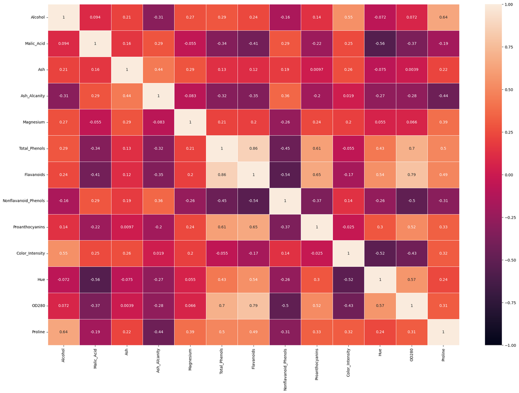

```python
import matplotlib.pyplot as plt
import seaborn as sns

plt.figure(figsize = (24,16))
ax  = sns.heatmap(correlations,  vmin=-1, vmax=1 ,  linewidth=.5,  annot=True)
```

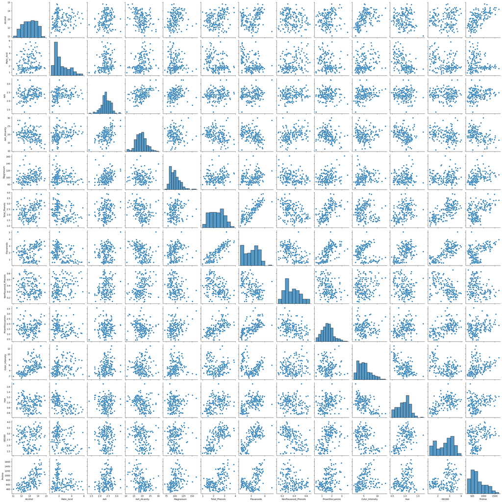

```python
sns.pairplot(df)
```

In order to see the data distribution, we can make a histogram:

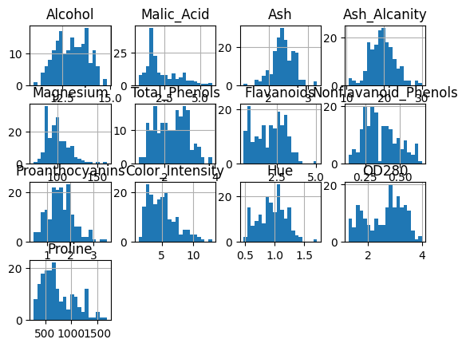

```python
plt.figure(figsize = [24,8],dpi = 110.0,layout ='compressed')
ax = df.hist(bins=20)
plt.show()
```

## Principal component analysis

Principal Component Analysis (PCA) is a statistical procedure that uses an orthogonal transformation to convert a set of observations of possibly correlated variables into a set of values of linearly uncorrelated variables called principal components. Mathematically, suppose we have a data matrix, X, with column-wise zero empirical mean (the sample mean of each column has been shifted to zero), where each of the n rows represents a different repetition of the experiment, and each of the p columns gives a particular kind of feature (say, the result from a particular sensor). The PCA transformation that preserves dimensionality (the number of nonzero principal components) is given by: $$ Y=X⋅V $$ where Y is a $n \times p$ matrix of T’s principal component scores, X is a n x p matrix of mean-centered input data, and V is a p x p matrix of weights whose columns are the eigenvectors of $X’X/n$. The jth column of Y is the jth principal component of X. The PCA transformation that reduces dimensionality can be written this way: $$ T=X⋅P $$ where T is a n x L matrix, X is a $n \times p$ matrix, and P is a $n \times L$ matrix. Columns of P are the eigenvectors of X’X/n corresponding to the L largest eigenvalues. The jth column of T, also known as score vector, has elements: $$ t_{ij} =\sum_{k=1}^{p}e_{kj}x_{ik} $$ where $t_{ij}$ is the score of the ith observation on the jth principal component. In other words, it is the projection of the ith observation onto the jth principal component.

The purpose of Principal Component Analysis (PCA) is multifold:

1. **Dimensionality Reduction**: In many domains such as machine learning and data mining, it is often the case that the raw data has too many dimensions, most of which are correlated. When the input data to an algorithm is too large, it can degrade the performance of the algorithm and it can also become difficult to visualize the data. PCA addresses this problem by constructing a small number of uncorrelated variables that succinctly convey the information in the original data.
2. **Noise Filtering**: PCA can also be used to filter noise from data. The idea in PCA is to discard the components with lesser variance because they are considered noise.
3. **Visualization**: High-dimensional data is hard to visualize. PCA transforms this high-dimensional data into 2D or 3D so that it can be visualized.
4. **Feature Extraction**: New features generated by PCA can sometimes be more informative than the original input features, so PCA can serve as a tool for feature extraction.

```python
from sklearn.preprocessing import StandardScaler
scale = StandardScaler()
cluster_ = df.copy()
cluster_[cluster_.columns] = scale.fit_transform(cluster_)
```

We proceed to do the dimensionality reduction with the PCA

```python
from sklearn.decomposition import PCA
pca = PCA()
X2D = pca.fit_transform(cluster_)
```

We check in graph the explained variance ratio as a cumulative sum:

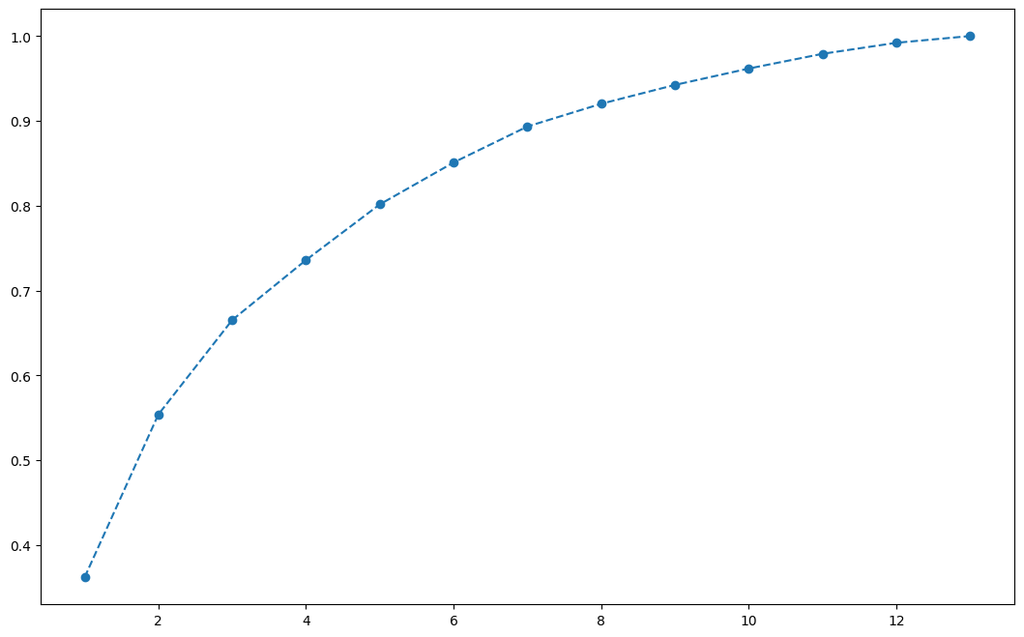

```python
plt.figure(figsize= (13,8))
plt.plot(range(1,14),pca.explained_variance_ratio_.cumsum(),marker = 'o',linestyle = '--')
```

A good parameter for the PCA, can be the dimension number that makes the cumulative sum greater than 0.95:

```python
cumsum = np.cumsum(pca.explained_variance_ratio_)
d = np.argmax(cumsum >= 0.95) + 1
```

```python
d
```

```
10
```

Anyhow, let's try different parameters search. First we make a randomized search:

```python
from sklearn.cluster import KMeans
from sklearn.model_selection import RandomizedSearchCV
from sklearn.metrics import silhouette_score
from sklearn.pipeline import make_pipeline

# Create a PCA object
pca = PCA()
# Create a KMeans object
kmeans = KMeans()

clf = make_pipeline(PCA(random_state=42),KMeans(n_init=1))

# Create a dictionary of parameters to search over
param_grid = {
    'pca__n_components': np.arange(2,11),
    'kmeans__n_clusters': [2, 3, 4, 5, 6]
}
# Create a RandomizedSearchCV object
rs_cv = RandomizedSearchCV(clf, param_grid,n_iter=20)
# Fit the RandomizedSearchCV object to the data
rs_cv.fit(cluster_)
# Print the best parameters
print(rs_cv.best_params_)
```

```
{'pca__n_components': 2, 'kmeans__n_clusters': 3}
```

Since the KMeans function can return different solutions, we will manually try it. First we check the results of this first model:

```python
# Get the best PCA and KMeans objects

best_pca = rs_cv.best_estimator_.named_steps['pca']
best_kmeans = rs_cv.best_estimator_.named_steps['kmeans']
```

Remember that the score function for KMeans is the Silhouette Score:

```python
# Transform the data using the best PCA object
pca_data = best_pca.transform(cluster_)
# Predict the cluster labels for the data using the best KMeans object
cluster_labels = best_kmeans.predict(pca_data)
# Calculate the silhouette score for the best PCA and KMeans objects
silhouette_sc = silhouette_score(pca_data, cluster_labels)
# Print the silhouette score
print(silhouette_sc)
```

```
0.5609305721582905
```

```python
cluster_labels
```

[output not shown]

We check the Silhouette Score for different clusters, without using PCA:

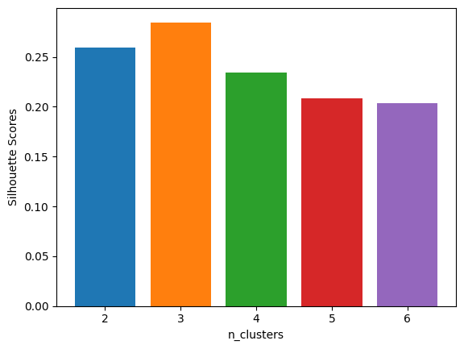

```python
plt.figure()
for n_clusters in param_grid['kmeans__n_clusters']:
    kmeans = KMeans(n_clusters=n_clusters,n_init='auto')
    cluster_labels = kmeans.fit_predict(cluster_)
    silhouette_scor = silhouette_score(cluster_, cluster_labels, metric='euclidean')
    plt.bar(n_clusters, silhouette_scor)
plt.xlabel('n_clusters')
plt.ylabel('Silhouette Scores')
plt.show()
```

Now, let's see by model our data by doing first a PCA, then a KMeans model by changing the different parameters.

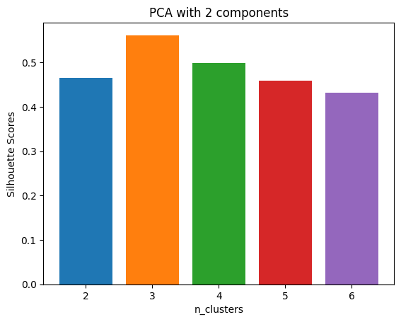

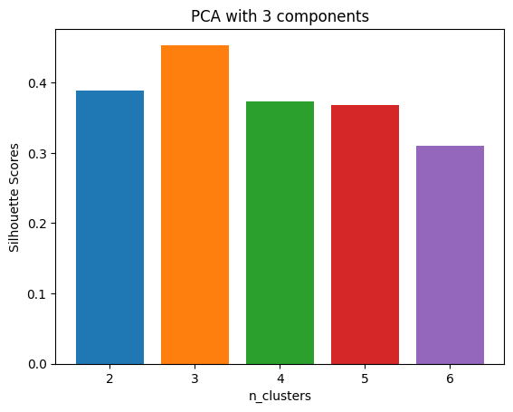

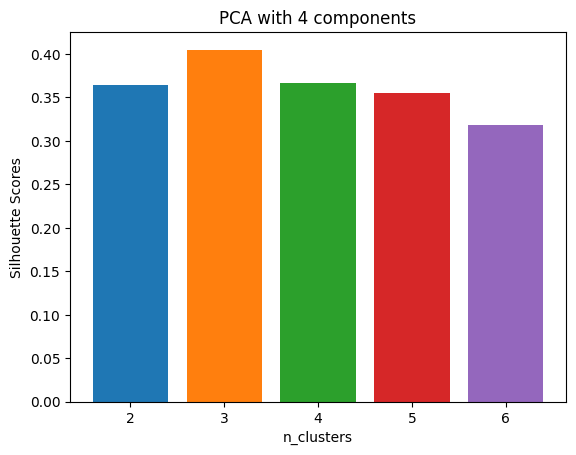

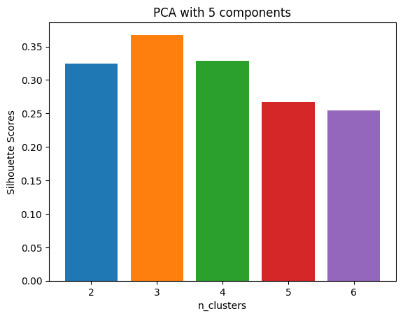

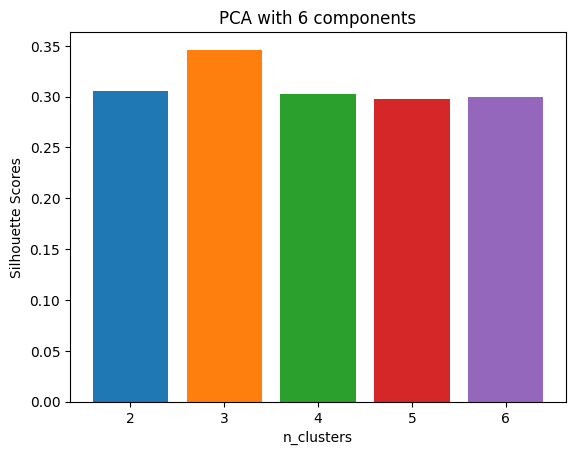

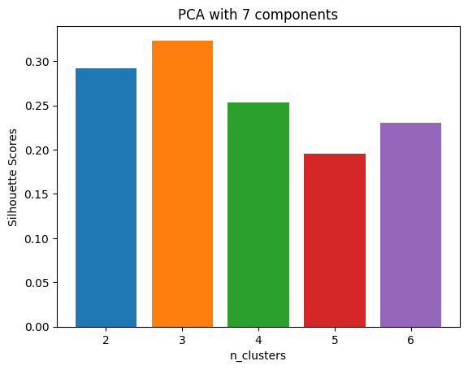

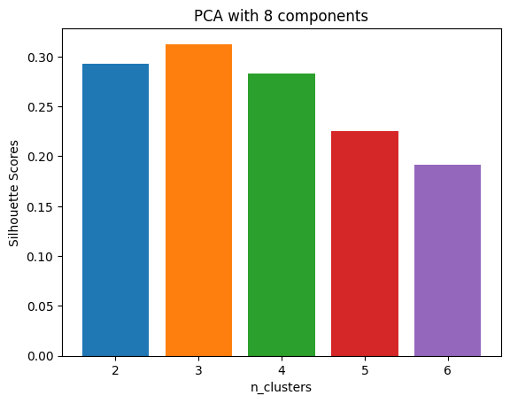

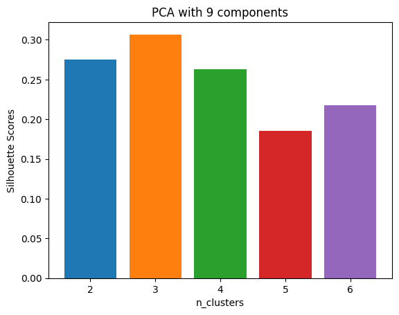

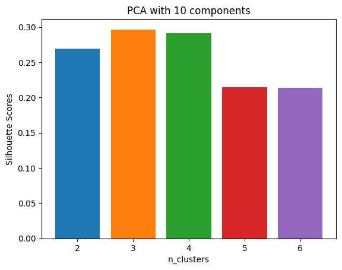

```python
# Plot the silhouette scores for the different parameters
plt.figure()
for n_components in param_grid['pca__n_components']:
    for n_clusters in param_grid['kmeans__n_clusters']:

        pca = PCA(n_components=n_components)
        kmeans = KMeans(n_clusters=n_clusters,n_init='auto')

        pca_data = pca.fit_transform(cluster_).round(2)
        cluster_labels = kmeans.fit_predict(pca_data)
        silhouette_scor = silhouette_score(pca_data, cluster_labels, metric='euclidean')
        plt.bar(n_clusters, silhouette_scor)
    plt.xlabel('n_clusters')
    plt.ylabel('Silhouette Scores')
    plt.title('PCA with '+ str (n_components) +' components')
    plt.show()
```

By looking at our barplots, the best model is the one that has 2 components and 3 clusters. We are going to check the difference by first not implementing the PCA in our model (we are only going to use it for a better representation of the clusters). Then, we are going to use it as a preprocessing for our model and for the data representation.

```python
pca = PCA(n_components=2)
kmeans = KMeans(n_clusters=3, n_init='auto', random_state=42)

pca_data = pca.fit_transform(cluster_).round(2)

X=pd.DataFrame(cluster_)
X_pca = pca.fit_transform(X)

# Convert to data frame
principal_df = pd.DataFrame(data = X_pca, columns = ['PC1', 'PC2'])
clusters = kmeans.fit_predict(cluster_)
# Cluster centers
centroids = kmeans.cluster_centers_
centroids_pca = pca.transform(centroids)
print(silhouette_score(cluster_, clusters, metric='euclidean') )
```

```
0.2844212860533542
```

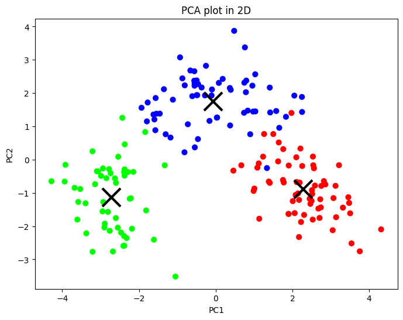

```python
# Figure size
plt.figure(figsize=(8,6))

# Scatterplot
plt.scatter(principal_df.iloc[:,0], principal_df.iloc[:,1], c=clusters, cmap="brg", s=40)
plt.scatter(x=centroids_pca[:,0], y=centroids_pca[:,1], marker="x", s=500, linewidths=3, color="black")

# Aesthetics
plt.title('PCA plot in 2D')
plt.xlabel('PC1')
plt.ylabel('PC2')
```

We can see that the blue cluster has some red elements, which are closer than other blue elements. If we implement the PCA in our model, we can see the difference:

```python
pca = PCA(n_components=2)
kmeans = KMeans(n_clusters=3, n_init='auto', random_state=42)

pca_data = pca.fit_transform(cluster_).round(2)

X=pd.DataFrame(cluster_)
X_pca = pca.fit_transform(X)

# Convert to data frame
principal_df = pd.DataFrame(data = X_pca, columns = ['PC1', 'PC2'])
clusters = kmeans.fit_predict(pca_data)
# Cluster centers
centroids = kmeans.cluster_centers_
print(silhouette_score(X_pca, clusters, metric='euclidean') )
```

```
0.5615238075263915
```

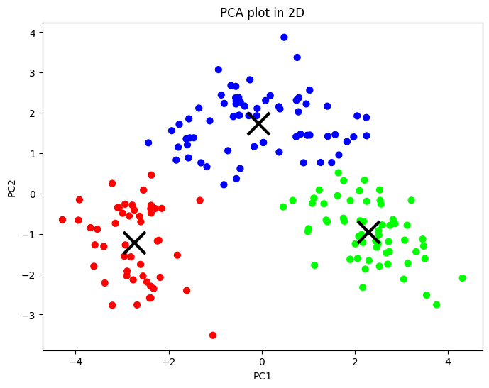

```python
# Figure size
plt.figure(figsize=(8,6))

# Scatterplot
plt.scatter(principal_df.iloc[:,0], principal_df.iloc[:,1], c=clusters, cmap="brg", s=40)
plt.scatter(x=centroids[:,0], y=centroids[:,1], marker="x", s=500, linewidths=3, color="black")

# Aesthetics
plt.title('PCA plot in 2D')
plt.xlabel('PC1')
plt.ylabel('PC2')
```